# Fixed Regression of Treatment BLUPs from multi-treatment MET anlyses

## Setup

### Simulated data and model

> **Requires:** ASReml-R V4. The vignette is pre-rendered so no licence is needed to read it; run the code chunks only if you have ASReml-R installed.

We use `simTrialData()` to generate a balanced multi-environment trial with 20 varieties, 4 sites, and 3 nitrogen treatments (T0 = control, T1 = low N, T2 = high N). Treatment effects are set to span a clear range so that the regression patterns are easy to interpret.

```r
out <- simTrialData(
  nvar        = 20L,
  nsite       = 4L,
  treatments  = c("T0", "T1", "T2"),
  nrep        = 3L,
  seed        = 42L,
  verbose     = FALSE,
  sim.options = list(treat_effects = c(0, 80, 200))
)
dat        <- out$data
levs       <- c("T0", "T1", "T2")
dat$Row    <- factor(dat$Row)
dat$Column <- factor(dat$Column)
```

We fit a **fixed Treatment × Site × Variety model** with site-within-replicate random effects and a spatial residual structure. Variety must be in the fixed effects so that `predict()` returns true BLUEs for every Treatment × Site × Variety combination — the raw material for the OLS regressions in `fixedRegress()`.

```r
asreml.options(trace = FALSE)
model <- asreml(
  yield    ~ Treatment * Site * Variety,
  random   = ~ at(Site):Rep,
  residual = ~ dsum(~ ar1(Row):ar1(Column) | Site),
  data     = dat,
  maxit    = 30L
)
model <- update(model)
```

### Running `fixedRegress()`

`fixedRegress()` calls `predict()` internally using the `term` argument as the `classify`. The `by` argument splits the analysis so that separate OLS regressions are performed within each site:

```r
res_base <- fixedRegress(
  model,
  term = "Treatment:Site:Variety",
  by   = "Site",
  levs = levs
)
```

The return value is a named list:

```r
str(res_base, max.level = 1)
```

```
List of 5
 $ blues    :'data.frame':  80 obs. of  11 variables:
 $ beta     :List of 2
 $ sigmat   : num [1:4, 1:2] 296 233 218 251 358 ...
  ..- attr(*, "dimnames")=List of 2
 $ cond_list:List of 3
 $ type     : chr "baseline"
```

The first few rows of `blues` show the raw BLUEs plus the response indices (`resp.*`) and their per-genotype standard errors (`se.*`) and Tukey HSDs (`HSD.*`):

```r
head(res_base$blues)
```

```
  Site Variety       T0       T1       T2    resp.T1    resp.T2    se.T1
1 Env1   Var01 4073.751 4000.454 4342.345  102.06894  248.06134 283.1984
2 Env1   Var02 3534.043 3811.166 3988.623   32.48865  145.19236 285.1068
3 Env1   Var03 4045.064 4346.521 4196.122  454.49895  115.17213 284.1779
4 Env1   Var04 3921.810 3124.864 3209.444 -739.82068 -814.21858 287.2430
5 Env1   Var05 3429.167 4027.333 3715.976  271.91770  -78.70887 281.4244
6 Env1   Var06 3809.034 3874.922 3958.344   35.25141  -12.90025 288.4557
     se.T2   HSD.T1   HSD.T2
1 342.9688 1668.087 2020.144
2 345.2800 1668.087 2020.144
3 344.1550 1668.087 2020.144
4 347.8671 1668.087 2020.144
5 340.8204 1668.087 2020.144
6 349.3357 1668.087 2020.144
```

## Example 1: Baseline conditioning

`type = "baseline"` (the default) regresses each non-first treatment on `levs[1]` (T0) alone — a simple OLS regression with one conditioning treatment per group. This is the most interpretable scheme: T0 BLUEs represent a genotype’s baseline performance; the response index for T1 and T2 represents how much each genotype over- or under-performs relative to what its T0 BLUE would predict.

```r
res_base <- fixedRegress(
  model,
  term = "Treatment:Site:Variety",
  by   = "Site",
  levs = levs,
  type = "baseline"
)
```

The OLS slopes $\hat{\beta}$ for each conditioned treatment within each site are stored in `res$beta`:

```r
res_base$beta$T1
```

```
  Site        T0
1 Env1 0.2218013
2 Env2 0.6520192
3 Env3 0.4322294
4 Env4 0.5424221
```

```r
res_base$beta$T2
```

```
  Site        T0
1 Env1 0.4647938
2 Env2 0.2615390
3 Env3 0.8299137
4 Env4 0.2024122
```

A slope $\hat{\beta} > 1$ means the conditioned treatment varies *more* across genotypes than the baseline; $\hat{\beta} < 1$ means it varies *less*. The residual standard deviations $\hat{\sigma}_{jk}$ (one per conditioned treatment per group) are in `res$sigmat`:

```r
res_base$sigmat
```

```
           T1       T2
Env1 296.0221 358.4990
Env2 232.6605 254.3904
Env3 217.7524 239.7626
Env4 250.5441 253.7067
```

## Example 2: Sequential conditioning

`type = "sequential"` performs a Gram–Schmidt orthogonalisation of the BLUE space. Treatment $j$ is regressed on all preceding treatments, so the response index for T2 captures the genetic variation in high-nitrogen response that is *not* already explained by baseline performance or low-nitrogen response.

```r
res_seq <- fixedRegress(
  model,
  term = "Treatment:Site:Variety",
  by   = "Site",
  levs = levs,
  type = "sequential"
)

# T2 is now conditioned on both T0 and T1
res_seq$cond_list
```

```
$T0
NULL

$T1
[1] "T0"

$T2
[1] "T0" "T1"
```

The beta data frame for T2 now has two slope columns — one for T0 and one for T1:

```r
res_seq$beta$T2
```

```
  Site        T0          T1
1 Env1 0.3095307  0.70000967
2 Env2 0.2719005 -0.01589145
3 Env3 0.6906464  0.32220700
4 Env4 0.3580469 -0.28692528
```

## Example 3: Partial conditioning

`type = "partial"` regresses each treatment on *all other* treatments simultaneously. The response index is the partial regression residual — the genetic variation in treatment $j$ that is independent of all other treatment BLUEs. This is the most conservative scheme: it removes the maximum amount of shared genetic variation before extracting the residual.

```r
res_part <- fixedRegress(
  model,
  term = "Treatment:Site:Variety",
  by   = "Site",
  levs = levs,
  type = "partial"
)

# T0 is now conditioned on T1 and T2; T1 on T0 and T2; T2 on T0 and T1
res_part$cond_list
```

```
$T0
[1] "T1" "T2"

$T1
[1] "T0" "T2"

$T2
[1] "T0" "T1"
```

## Example 4: Custom conditioning

`type = "custom"` gives full control over the conditioning structure via the `cond` argument. A treatment with `NULL` in `cond` is left unconditional (its BLUE is used as-is). This is useful when the experimental design implies a specific hierarchy — for example, treating T0 as the unconditional baseline and using a custom asymmetric conditioning for T1 and T2.

```r
res_cust <- fixedRegress(
  model,
  term = "Treatment:Site:Variety",
  by   = "Site",
  levs = levs,
  type = "custom",
  cond = list(T0 = NULL,          # unconditional
              T1 = "T0",          # T1 | T0  (same as baseline)
              T2 = c("T0", "T1")) # T2 | T0 + T1 (same as sequential)
)

res_cust$cond_list
```

```
$T1
[1] "T0"

$T2
[1] "T0" "T1"
```

This particular `cond` specification reproduces the sequential scheme for a three-treatment design.

## Regression plot — `type = "regress"`

The regression plot shows the raw BLUEs of each conditioned treatment (y-axis) against the BLUEs of its conditioning treatment (x-axis). Each panel corresponds to one group × treatment pair. A **dotted OLS regression line** is drawn through the data with the slope $\hat{\beta}$ annotated in the top-left corner of each panel.

Unlike the random-effects analogue, the OLS line **does not pass through the origin** because BLUEs retain the treatment fixed-effect mean. With `centre = TRUE` (the default), within-group means are subtracted from both axes so that the zero reference lines fall at the centre of each panel and the above/below-average split has a clear biological meaning.

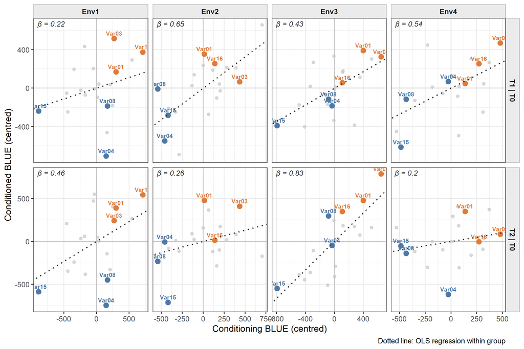

```r
p_reg <- plot_fixedRegress(res_base, type = "regress")
print(p_reg)
```

With `centre = FALSE` the raw BLUEs are displayed on their original scale. Reference lines are drawn at the within-group treatment means (rather than zero) to preserve the above/below-average interpretation:

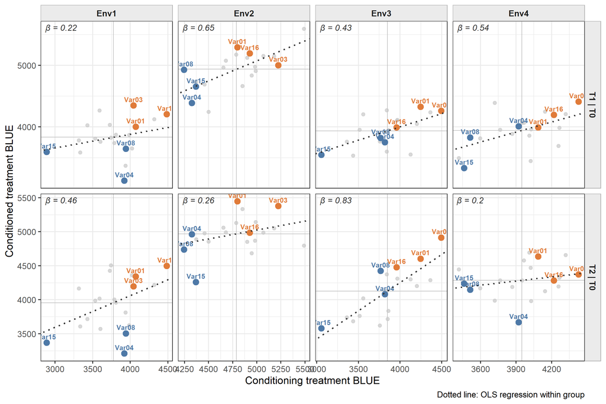

```r
p_reg_raw <- plot_fixedRegress(res_base, type = "regress", centre = FALSE)
print(p_reg_raw)
```

## Quadrant plot — `type = "quadrant"`

The quadrant plot shows the two components of treatment response directly: the **x-axis** carries the unconditional T0 BLUE (efficiency) and the **y-axis** carries the response index (OLS residual). Dotted zero reference lines divide each panel into four quadrants.

The response index y-axis is always zero-centred (OLS residuals are mean-zero by construction). The x-axis is centred by subtracting within-group means when `centre = TRUE` (the default), keeping the quadrant interpretation valid:

| Quadrant | Efficiency | Response index | Interpretation |
| --- | --- | --- | --- |
| Top-right | High | High | Broadly adapted: strong baseline and extra treatment response |
| Top-left | Low | High | Responsive to treatment despite low baseline |
| Bottom-right | High | Low | High baseline but limited extra response to inputs |
| Bottom-left | Low | Low | Below average on both components |

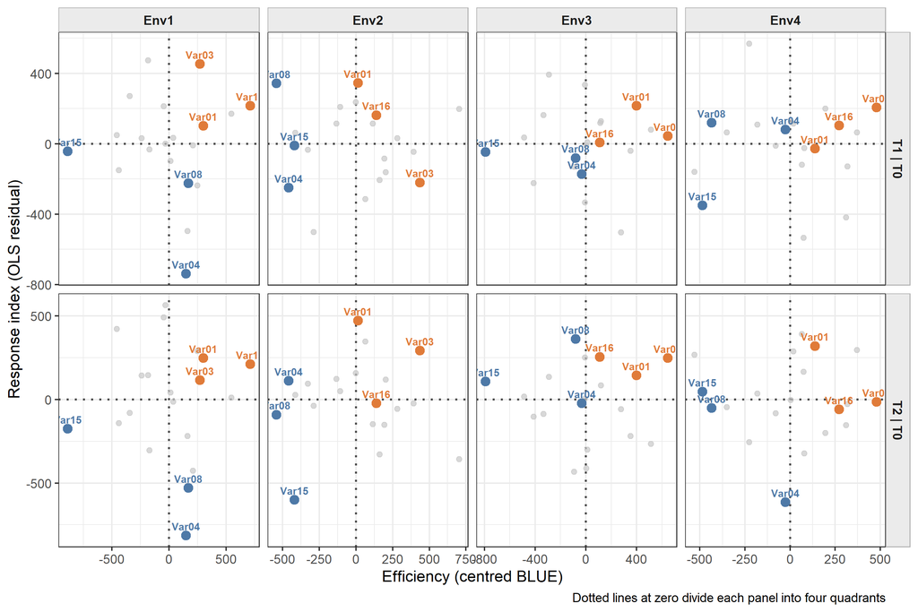

```r
p_quad <- plot_fixedRegress(res_base, type = "quadrant")
print(p_quad)
```

## Genotype highlighting

By default, `highlight = "default"` automatically selects and annotates **six genotypes** that are informative archetypes of the efficiency–response space. The algorithm is identical to the one used in `plot_randomRegress()`.

### How the default algorithm works

1. Compute the mean efficiency (x) and response index (y) for each genotype **across all groups and treatment pairs** using the centred quadrant data (regardless of the `centre` display setting).
2. Separate genotypes into the **top-right** quadrant ($x > 0$, $y > 0$) and the **bottom-left** quadrant ($x < 0$, $y < 0$).
3. Within each quadrant, retain genotypes whose distance from the origin exceeds the 50th percentile (relaxes to 33rd then 0th if fewer than three candidates remain).
4. Pick three archetypes by polar angle $\theta = \arctan(|y|/|x|)$:
   - **Efficiency archetype** — smallest $\theta$ (near the x-axis)
   - **Balanced archetype** — closest to $\theta = \pi/4$
   - **Response archetype** — largest $\theta$ (near the y-axis)

Orange labels = top-right archetypes; blue labels = bottom-left archetypes. The same six genotypes are annotated across all panels.

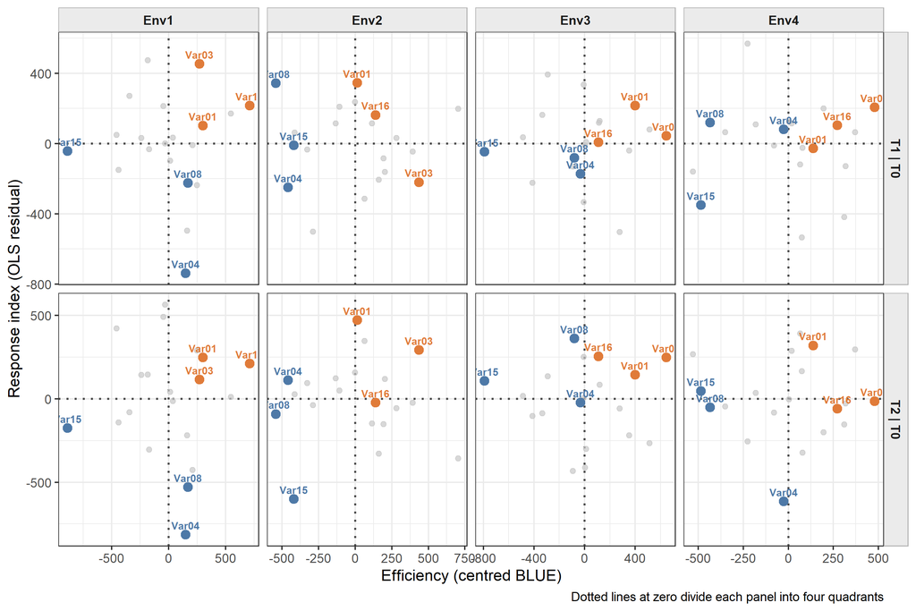

```r
p_hl <- plot_fixedRegress(res_base, type = "quadrant", highlight = "default")
print(p_hl)
```

### User-specified highlights

Pass a character vector of genotype names to annotate specific genotypes of interest (shown in green):

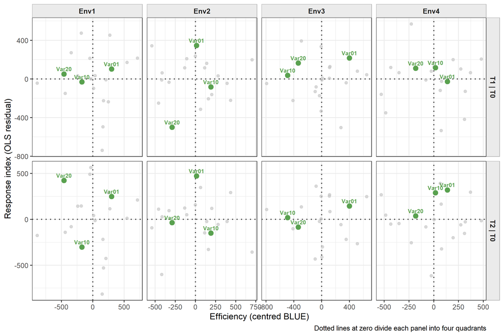

```r
user_genos <- levels(factor(res_base$blues$Variety))[c(1L, 10L, 20L)]
p_custom   <- plot_fixedRegress(res_base, type  = "quadrant",
                                 highlight = user_genos)
print(p_custom)
```

### No highlighting

Set `highlight = NULL` to suppress annotation entirely:

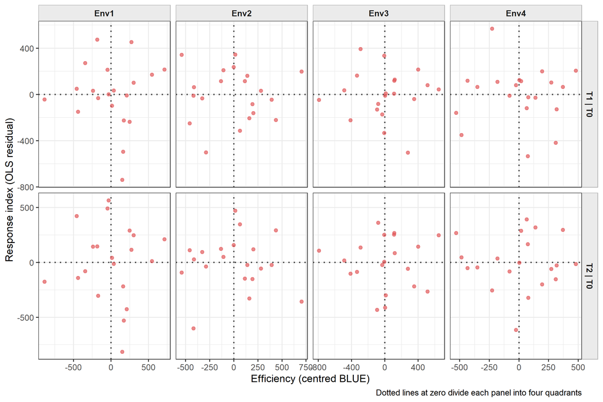

```r
p_none <- plot_fixedRegress(res_base, type = "quadrant", highlight = NULL)
print(p_none)
```

## Filtering treatments — `treatments` argument

For results with many conditioned treatments, `treatments` restricts which pairs appear in the plot. Here we show T2 only:

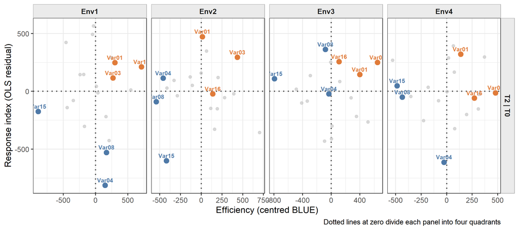

```r
p_t2 <- plot_fixedRegress(res_base, type = "quadrant", treatments = "T2")
print(p_t2)
```

## Extracting plot data — `return_data = TRUE`

Both plot types support `return_data = TRUE`, which returns the tidy data frame used to build the plot. Column names are standardised to `"Group"` and `"Genotype"` regardless of the original column names in `res$blues`:

```r
df_quad <- plot_fixedRegress(res_base, type = "quadrant", return_data = TRUE)
head(df_quad)
```

```
  Group Genotype          x          y pair_label
1  Env1    Var01  299.42588  102.06894    T1 | T0
2  Env1    Var02 -240.28249   32.48865    T1 | T0
3  Env1    Var03  270.73912  454.49895    T1 | T0
4  Env1    Var04  147.48456 -739.82068    T1 | T0
5  Env1    Var05 -345.15840  271.91770    T1 | T0
6  Env1    Var06   34.70851   35.25141    T1 | T0
```

```r
df_reg <- plot_fixedRegress(res_base, type = "regress", return_data = TRUE)
names(df_reg)
```

```
[1] "Group"      "pair_label" "Genotype"   "x"          "y"
[6] "beta"       "intercept"
```

The returned data frame can be passed directly into any `ggplot2` workflow:

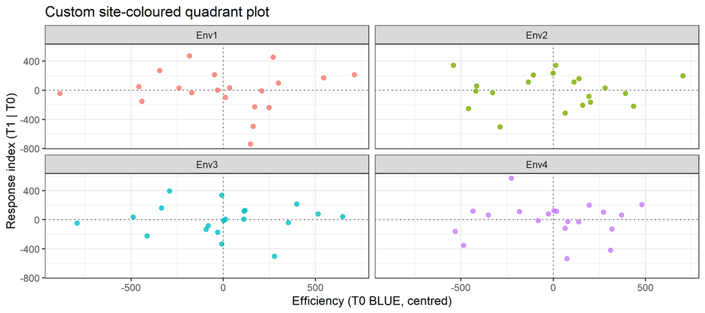

```r
# Custom plot: T1 quadrant only, colour by site
df_t1 <- plot_fixedRegress(res_base, type = "quadrant",
                            treatments  = "T1",
                            return_data = TRUE)

ggplot(df_t1, aes(x = x, y = y, colour = Group)) +
  geom_hline(yintercept = 0, linetype = "dotted", colour = "grey40") +
  geom_vline(xintercept = 0, linetype = "dotted", colour = "grey40") +
  geom_point(size = 1.8, alpha = 0.8) +
  facet_wrap(~ Group, nrow = 2L) +
  labs(
    x     = "Efficiency (T0 BLUE, centred)",
    y     = "Response index (T1 | T0)",
    title = "Custom site-coloured quadrant plot"
  ) +
  theme_bw() +
  theme(legend.position = "none")
```

The ggplot object returned by `plot_fixedRegress()` can also be extended directly with `+`:

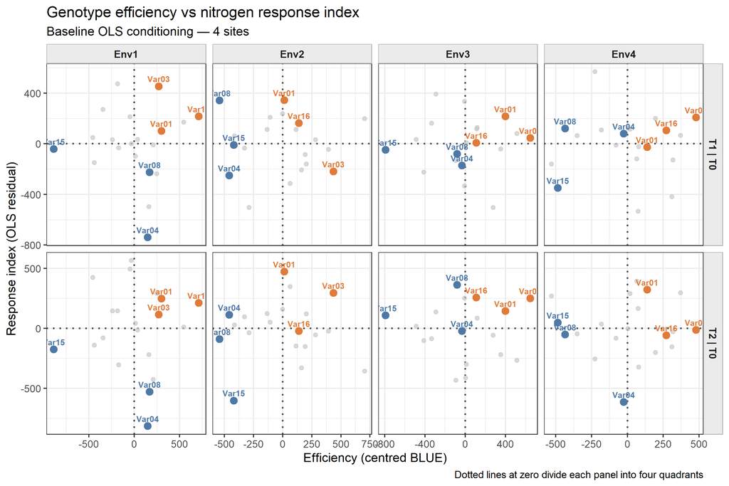

```r
p_titled <- plot_fixedRegress(res_base, type = "quadrant") +
  ggplot2::ggtitle(
    "Genotype efficiency vs nitrogen response index",
    subtitle = "Baseline OLS conditioning — 4 sites"
  )
print(p_titled)
```

## Return value summary

`fixedRegress()` returns a named list:

| Element | Type | Description |
| --- | --- | --- |
| `blues` | Data frame | Raw BLUEs + response indices (`resp.*`) + standard errors (`se.*`) + Tukey HSD (`HSD.*`) per genotype × group |
| `beta` | Named list | One data frame per conditioned treatment; each data frame has the grouping column plus one slope column per conditioning treatment |
| `sigmat` | Matrix | Residual standard deviations $\hat{\sigma}_{jk}$, dimensions $n_\text{groups} \times n_\text{cond}$ |
| `cond_list` | Named list | Resolved conditioning structure |
| `type` | Character | Conditioning scheme used |

## Summary

| Task | Argument / specification |
| --- | --- |
| Baseline conditioning | `type = "baseline"` (default) |
| Orthogonal (Gram–Schmidt) | `type = "sequential"` |
| Partial regression residuals | `type = "partial"` |
| Bespoke conditioning | `type = "custom", cond = list(...)` |
| Split by site / group | `by = "Site"` |
| No grouping (one regression) | `by = NULL` (default) |
| Regression scatter plot | `plot_fixedRegress(res, type = "regress")` |
| Efficiency–response index plot | `plot_fixedRegress(res, type = "quadrant")` |
| Default archetype highlights | `highlight = "default"` |
| Named genotype highlights | `highlight = c("Gen01", "Gen15")` |
| Suppress highlights | `highlight = NULL` |
| Restrict treatments shown | `treatments = "T2"` |
| Centred axes (default) | `centre = TRUE` |
| Raw BLUE scale | `centre = FALSE` |
| Export plot data | `return_data = TRUE` |

## References

Lemerle, D., Smith, A., Verbeek, B., Koetz, E., Lockley, P. & Martin, P. (2006). Incremental crop tolerance to weeds: A measure for selecting competitive ability in Australian wheats. *Euphytica*, **149**, 85–95. https://doi.org/10.1007/s10681-005-9056-5

McDonald G, Bovill W, Taylor J, Wheeler R. (2015) Responses to phosphorus among wheat genotypes. *Crop and Pasture Science*, **66**(5), 430–444. (2015). https://doi.org/10.1071/CP14191

The WtmsDW Locus on Wheat Chromosome 2B Controls Major Natural Variation for Floret Sterility Responses to Heat Stress at Booting Stage. *Frontiers in Plant Science*, **12**, 635397. (2021). https://doi.org/10.3389/fpls.2021.635397